# Udacity Project 1

## Poject: Investigate a Dataset - TMDB 5000 Movie Dataset

## NAME : DENIS KIPRONO

## Introduction

### Dataset Describtion

TMDB 5000 Movie dataset contains information about movies collected from The Movie Database (TMDb). My purpose of using this dataset is to be able to answer formulated questions based of analysis using python. By using this dataset I agree with terms and condition provided.

### Questions for analysis

Every organizational setup is interested on all the efforts that would put every action they take at optimal state so as to naximize earning their profits. In this era informative steps for decision making is relied of data that the company has based on expertize findings by data analyst. I am here to analyse this movie dataset so that I uncover some hidden trends and be able to communicate my findings and conclusion which subject expert can easily vet as proposal to be considered.

#### Question 1

Directors play a greater role in movie productions. I want to run the best director awards and for this reason I want look into the intereactions between director variable with others so that I can determine whom will win the awards.

#### Question 2.

Optimizing resources is important aspect when it comes to any business setup. I am interested on how to play cards so that I realize best best variables to keep into consideration against months of the year. By this I mean which is the best for movie industry to release their product.

# Section 1 : Libraries importatation, Read csv and load dataframes, overview of the dataframes.

```python
# Here I imported libraries that are critical so as to allow me successfully complete my data analysis task
import numpy as np # to enable me work with numerical data easily and faster
import pandas as pd # to allow manipulationof dataframes like reading csv files.
import matplotlib.pyplot as plt # for plotting purposes
import seaborn as sb # Rendering visuals nicely
import ast
dfm = pd.read_csv('tmdb-movies.csv') # read tmdb-movies and load it to movies dataframe as dfm
```

```python
dfm #shows the dataframe data by defaunt first 5 rows
```

|  | id | imdb_id | popularity | budget | revenue | original_title | cast | homepage | director | tagline | ... | overview | runtime | genres | production_companies | release_date | vote_count | vote_average | release_year | budget_adj | revenue_adj |
| --- | --- | --- | --- | --- | --- | --- | --- | --- | --- | --- | --- | --- | --- | --- | --- | --- | --- | --- | --- | --- | --- |
| 0 | 135397 | tt0369610 | 32.985763 | 150000000 | 1513528810 | Jurassic World | Chris Pratt\|Bryce Dallas Howard\|Irrfan Khan\|Vi... | http://www.jurassicworld.com/ | Colin Trevorrow | The park is open. | ... | Twenty-two years after the events of Jurassic ... | 124 | Action\|Adventure\|Science Fiction\|Thriller | Universal Studios\|Amblin Entertainment\|Legenda... | 6/9/15 | 5562 | 6.5 | 2015 | 1.379999e+08 | 1.392446e+09 |
| 1 | 76341 | tt1392190 | 28.419936 | 150000000 | 378436354 | Mad Max: Fury Road | Tom Hardy\|Charlize Theron\|Hugh Keays-Byrne\|Nic... | http://www.madmaxmovie.com/ | George Miller | What a Lovely Day. | ... | An apocalyptic story set in the furthest reach... | 120 | Action\|Adventure\|Science Fiction\|Thriller | Village Roadshow Pictures\|Kennedy Miller Produ... | 5/13/15 | 6185 | 7.1 | 2015 | 1.379999e+08 | 3.481613e+08 |
| 2 | 262500 | tt2908446 | 13.112507 | 110000000 | 295238201 | Insurgent | Shailene Woodley\|Theo James\|Kate Winslet\|Ansel... | http://www.thedivergentseries.movie/#insurgent | Robert Schwentke | One Choice Can Destroy You | ... | Beatrice Prior must confront her inner demons ... | 119 | Adventure\|Science Fiction\|Thriller | Summit Entertainment\|Mandeville Films\|Red Wago... | 3/18/15 | 2480 | 6.3 | 2015 | 1.012000e+08 | 2.716190e+08 |
| 3 | 140607 | tt2488496 | 11.173104 | 200000000 | 2068178225 | Star Wars: The Force Awakens | Harrison Ford\|Mark Hamill\|Carrie Fisher\|Adam D... | http://www.starwars.com/films/star-wars-episod... | J.J. Abrams | Every generation has a story. | ... | Thirty years after defeating the Galactic Empi... | 136 | Action\|Adventure\|Science Fiction\|Fantasy | Lucasfilm\|Truenorth Productions\|Bad Robot | 12/15/15 | 5292 | 7.5 | 2015 | 1.839999e+08 | 1.902723e+09 |
| 4 | 168259 | tt2820852 | 9.335014 | 190000000 | 1506249360 | Furious 7 | Vin Diesel\|Paul Walker\|Jason Statham\|Michelle ... | http://www.furious7.com/ | James Wan | Vengeance Hits Home | ... | Deckard Shaw seeks revenge against Dominic Tor... | 137 | Action\|Crime\|Thriller | Universal Pictures\|Original Film\|Media Rights ... | 4/1/15 | 2947 | 7.3 | 2015 | 1.747999e+08 | 1.385749e+09 |
| ... | ... | ... | ... | ... | ... | ... | ... | ... | ... | ... | ... | ... | ... | ... | ... | ... | ... | ... | ... | ... | ... |
| 10861 | 21 | tt0060371 | 0.080598 | 0 | 0 | The Endless Summer | Michael Hynson\|Robert August\|Lord 'Tally Ho' B... | NaN | Bruce Brown | NaN | ... | The Endless Summer, by Bruce Brown, is one of ... | 95 | Documentary | Bruce Brown Films | 6/15/66 | 11 | 7.4 | 1966 | 0.000000e+00 | 0.000000e+00 |
| 10862 | 20379 | tt0060472 | 0.065543 | 0 | 0 | Grand Prix | James Garner\|Eva Marie Saint\|Yves Montand\|Tosh... | NaN | John Frankenheimer | Cinerama sweeps YOU into a drama of speed and ... | ... | Grand Prix driver Pete Aron is fired by his te... | 176 | Action\|Adventure\|Drama | Cherokee Productions\|Joel Productions\|Douglas ... | 12/21/66 | 20 | 5.7 | 1966 | 0.000000e+00 | 0.000000e+00 |
| 10863 | 39768 | tt0060161 | 0.065141 | 0 | 0 | Beregis Avtomobilya | Innokentiy Smoktunovskiy\|Oleg Efremov\|Georgi Z... | NaN | Eldar Ryazanov | NaN | ... | An insurance agent who moonlights as a carthie... | 94 | Mystery\|Comedy | Mosfilm | 1/1/66 | 11 | 6.5 | 1966 | 0.000000e+00 | 0.000000e+00 |
| 10864 | 21449 | tt0061177 | 0.064317 | 0 | 0 | What's Up, Tiger Lily? | Tatsuya Mihashi\|Akiko Wakabayashi\|Mie Hama\|Joh... | NaN | Woody Allen | WOODY ALLEN STRIKES BACK! | ... | In comic Woody Allen's film debut, he took the... | 80 | Action\|Comedy | Benedict Pictures Corp. | 11/2/66 | 22 | 5.4 | 1966 | 0.000000e+00 | 0.000000e+00 |
| 10865 | 22293 | tt0060666 | 0.035919 | 19000 | 0 | Manos: The Hands of Fate | Harold P. Warren\|Tom Neyman\|John Reynolds\|Dian... | NaN | Harold P. Warren | It's Shocking! It's Beyond Your Imagination! | ... | A family gets lost on the road and stumbles up... | 74 | Horror | Norm-Iris | 11/15/66 | 15 | 1.5 | 1966 | 1.276423e+05 | 0.000000e+00 |

10866 rows × 21 columns

We can now clear see clear some of the columns have the data store as lists nested in strings. This will be addressed in data cleaning section.

```python
dfm.shape  # shows the number of columns and rows of movies dfm dataframe
```

```
(10866, 21)
```

Movies dataframe has a total of 10866 rows of data and 21 columns.

```python
dfm.columns # returns the list of columns of dfm dataframe
```

```
Index(['id', 'imdb_id', 'popularity', 'budget', 'revenue', 'original_title',
       'cast', 'homepage', 'director', 'tagline', 'keywords', 'overview',
       'runtime', 'genres', 'production_companies', 'release_date',
       'vote_count', 'vote_average', 'release_year', 'budget_adj',
       'revenue_adj'],
      dtype='object')
```

```python
dfm.describe() # return summary statistics of the dataframe for values which are numeric
```

|  | id | popularity | budget | revenue | runtime | vote_count | vote_average | release_year | budget_adj | revenue_adj |
| --- | --- | --- | --- | --- | --- | --- | --- | --- | --- | --- |
| count | 10866.000000 | 10866.000000 | 1.086600e+04 | 1.086600e+04 | 10866.000000 | 10866.000000 | 10866.000000 | 10866.000000 | 1.086600e+04 | 1.086600e+04 |
| mean | 66064.177434 | 0.646441 | 1.462570e+07 | 3.982332e+07 | 102.070863 | 217.389748 | 5.974922 | 2001.322658 | 1.755104e+07 | 5.136436e+07 |
| std | 92130.136561 | 1.000185 | 3.091321e+07 | 1.170035e+08 | 31.381405 | 575.619058 | 0.935142 | 12.812941 | 3.430616e+07 | 1.446325e+08 |
| min | 5.000000 | 0.000065 | 0.000000e+00 | 0.000000e+00 | 0.000000 | 10.000000 | 1.500000 | 1960.000000 | 0.000000e+00 | 0.000000e+00 |
| 25% | 10596.250000 | 0.207583 | 0.000000e+00 | 0.000000e+00 | 90.000000 | 17.000000 | 5.400000 | 1995.000000 | 0.000000e+00 | 0.000000e+00 |
| 50% | 20669.000000 | 0.383856 | 0.000000e+00 | 0.000000e+00 | 99.000000 | 38.000000 | 6.000000 | 2006.000000 | 0.000000e+00 | 0.000000e+00 |
| 75% | 75610.000000 | 0.713817 | 1.500000e+07 | 2.400000e+07 | 111.000000 | 145.750000 | 6.600000 | 2011.000000 | 2.085325e+07 | 3.369710e+07 |
| max | 417859.000000 | 32.985763 | 4.250000e+08 | 2.781506e+09 | 900.000000 | 9767.000000 | 9.200000 | 2015.000000 | 4.250000e+08 | 2.827124e+09 |

We can quickly see the overview of dataframe and be able to draw some quick insights like we notice that in some of categories except id column which it shouldn't have been included in this summary had 0 as their minimum values meaning there were some entries which had those values. We can also note that budget and revenue had valueas which need to be investigate because min, 25%, and 50% has zero values.

```python
dfm.info() # shows the overview of the the dataframe
```

```
<class 'pandas.core.frame.DataFrame'>
RangeIndex: 10866 entries, 0 to 10865
Data columns (total 21 columns):
 #   Column                Non-Null Count  Dtype
---  ------                --------------  -----
 0   id                    10866 non-null  int64
 1   imdb_id               10856 non-null  object
 2   popularity            10866 non-null  float64
 3   budget                10866 non-null  int64
 4   revenue               10866 non-null  int64
 5   original_title        10866 non-null  object
 6   cast                  10790 non-null  object
 7   homepage              2936 non-null   object
 8   director              10822 non-null  object
 9   tagline               8042 non-null   object
 10  keywords              9373 non-null   object
 11  overview              10862 non-null  object
 12  runtime               10866 non-null  int64
 13  genres                10843 non-null  object
 14  production_companies  9836 non-null   object
 15  release_date          10866 non-null  object
 16  vote_count            10866 non-null  int64
 17  vote_average          10866 non-null  float64
 18  release_year          10866 non-null  int64
 19  budget_adj            10866 non-null  float64
 20  revenue_adj           10866 non-null  float64
dtypes: float64(4), int64(6), object(11)
memory usage: 1.7+ MB
```

We can notice that cast, homepage, director, tagline, keywords, overview, genres and production companies columns have missing values. Also release_date and release year have be assigned datatypes of string and integer respectively instead of datetime data type. This will be adddressed in data cleaning and wrangling section.

```python
dfm.duplicated().sum() # returns the number of duplicated entries in the movies dataframe.
```

```
1
```

# Section 2 : Data Cleaning and wrangling

The purpose of this section is to prepare dataframes by removing bad values, Renaming some columns, removing some irrevant columns with respect to questions posed, removing duplicates, filling or removing missing values. Merging and spliting some columns. Fixing datatypes and lastly merging datasets.

```python
# I need to drop irrelevat columns for my queatsions.
dfm = dfm.drop(['id','imdb_id','budget','revenue','original_title','homepage','tagline','overview', 'keywords'], axis=1)
```

```python
#let us confirm the shape
dfm.shape
```

```
(10866, 12)
```

You can see that I have removed 9 columns

```python
dfm.info()
```

```
<class 'pandas.core.frame.DataFrame'>
RangeIndex: 10866 entries, 0 to 10865
Data columns (total 12 columns):
 #   Column                Non-Null Count  Dtype
---  ------                --------------  -----
 0   popularity            10866 non-null  float64
 1   cast                  10790 non-null  object
 2   director              10822 non-null  object
 3   runtime               10866 non-null  int64
 4   genres                10843 non-null  object
 5   production_companies  9836 non-null   object
 6   release_date          10866 non-null  object
 7   vote_count            10866 non-null  int64
 8   vote_average          10866 non-null  float64
 9   release_year          10866 non-null  int64
 10  budget_adj            10866 non-null  float64
 11  revenue_adj           10866 non-null  float64
dtypes: float64(4), int64(3), object(5)
memory usage: 1018.8+ KB
```

```python
dfm.isnull().sum()
```

```
popularity                 0
cast                      76
director                  44
runtime                    0
genres                    23
production_companies    1030
release_date               0
vote_count                 0
vote_average               0
release_year               0
budget_adj                 0
revenue_adj                0
dtype: int64
```

It is important that I drop any rows that have null values for effective analysis

```python
# drops all rows that have null values
dfm.dropna(inplace=True)
```

```python
# confirm if we don't any null value
dfm.isnull().sum()
```

```
popularity              0
cast                    0
director                0
runtime                 0
genres                  0
production_companies    0
release_date            0
vote_count              0
vote_average            0
release_year            0
budget_adj              0
revenue_adj             0
dtype: int64
```

```python
dfm.info()
```

```
<class 'pandas.core.frame.DataFrame'>
Int64Index: 9773 entries, 0 to 10865
Data columns (total 12 columns):
 #   Column                Non-Null Count  Dtype
---  ------                --------------  -----
 0   popularity            9773 non-null   float64
 1   cast                  9773 non-null   object
 2   director              9773 non-null   object
 3   runtime               9773 non-null   int64
 4   genres                9773 non-null   object
 5   production_companies  9773 non-null   object
 6   release_date          9773 non-null   object
 7   vote_count            9773 non-null   int64
 8   vote_average          9773 non-null   float64
 9   release_year          9773 non-null   int64
 10  budget_adj            9773 non-null   float64
 11  revenue_adj           9773 non-null   float64
dtypes: float64(4), int64(3), object(5)
memory usage: 992.6+ KB
```

We can see that dropping null values has affect the shape of dataset but it is critical for effective analysis

The following line puts Cast, genres and production companies values into a proper list

```python
ndfm=dfm.copy()
ndfm['cast']=ndfm['cast'].str.split('|')
ndfm['genres']=ndfm['genres'].str.split('|')
ndfm['production_companies']=ndfm['production_companies'].str.split('|')
```

```python
ndfm['release_date']=pd.to_datetime(ndfm['release_date'],dayfirst=True)
```

```python
ndfm['release_year']=pd.to_datetime(ndfm['release_year'],yearfirst=True)
```

```python
udfm=ndfm.copy()
```

```python
udfm['release_month']=udfm['release_date'].dt.month
udfm['released_year']=udfm['release_date'].dt.year
```

```python
udfm['profit']=udfm['revenue_adj']-udfm['budget_adj']
```

```python
udfm
```

|  | popularity | cast | director | runtime | genres | production_companies | release_date | vote_count | vote_average | release_year | budget_adj | revenue_adj | release_month | released_year | profit |
| --- | --- | --- | --- | --- | --- | --- | --- | --- | --- | --- | --- | --- | --- | --- | --- |
| 0 | 32.985763 | [Chris Pratt, Bryce Dallas Howard, Irrfan Khan... | Colin Trevorrow | 124 | [Action, Adventure, Science Fiction, Thriller] | [Universal Studios, Amblin Entertainment, Lege... | 2015-09-06 | 5562 | 6.5 | 1970-01-01 00:00:00.000002015 | 1.379999e+08 | 1.392446e+09 | 9 | 2015 | 1.254446e+09 |
| 1 | 28.419936 | [Tom Hardy, Charlize Theron, Hugh Keays-Byrne,... | George Miller | 120 | [Action, Adventure, Science Fiction, Thriller] | [Village Roadshow Pictures, Kennedy Miller Pro... | 2015-05-13 | 6185 | 7.1 | 1970-01-01 00:00:00.000002015 | 1.379999e+08 | 3.481613e+08 | 5 | 2015 | 2.101614e+08 |
| 2 | 13.112507 | [Shailene Woodley, Theo James, Kate Winslet, A... | Robert Schwentke | 119 | [Adventure, Science Fiction, Thriller] | [Summit Entertainment, Mandeville Films, Red W... | 2015-03-18 | 2480 | 6.3 | 1970-01-01 00:00:00.000002015 | 1.012000e+08 | 2.716190e+08 | 3 | 2015 | 1.704191e+08 |
| 3 | 11.173104 | [Harrison Ford, Mark Hamill, Carrie Fisher, Ad... | J.J. Abrams | 136 | [Action, Adventure, Science Fiction, Fantasy] | [Lucasfilm, Truenorth Productions, Bad Robot] | 2015-12-15 | 5292 | 7.5 | 1970-01-01 00:00:00.000002015 | 1.839999e+08 | 1.902723e+09 | 12 | 2015 | 1.718723e+09 |
| 4 | 9.335014 | [Vin Diesel, Paul Walker, Jason Statham, Miche... | James Wan | 137 | [Action, Crime, Thriller] | [Universal Pictures, Original Film, Media Righ... | 2015-01-04 | 2947 | 7.3 | 1970-01-01 00:00:00.000002015 | 1.747999e+08 | 1.385749e+09 | 1 | 2015 | 1.210949e+09 |
| ... | ... | ... | ... | ... | ... | ... | ... | ... | ... | ... | ... | ... | ... | ... | ... |
| 10861 | 0.080598 | [Michael Hynson, Robert August, Lord 'Tally Ho... | Bruce Brown | 95 | [Documentary] | [Bruce Brown Films] | 2066-06-15 | 11 | 7.4 | 1970-01-01 00:00:00.000001966 | 0.000000e+00 | 0.000000e+00 | 6 | 2066 | 0.000000e+00 |
| 10862 | 0.065543 | [James Garner, Eva Marie Saint, Yves Montand, ... | John Frankenheimer | 176 | [Action, Adventure, Drama] | [Cherokee Productions, Joel Productions, Dougl... | 2066-12-21 | 20 | 5.7 | 1970-01-01 00:00:00.000001966 | 0.000000e+00 | 0.000000e+00 | 12 | 2066 | 0.000000e+00 |
| 10863 | 0.065141 | [Innokentiy Smoktunovskiy, Oleg Efremov, Georg... | Eldar Ryazanov | 94 | [Mystery, Comedy] | [Mosfilm] | 2066-01-01 | 11 | 6.5 | 1970-01-01 00:00:00.000001966 | 0.000000e+00 | 0.000000e+00 | 1 | 2066 | 0.000000e+00 |
| 10864 | 0.064317 | [Tatsuya Mihashi, Akiko Wakabayashi, Mie Hama,... | Woody Allen | 80 | [Action, Comedy] | [Benedict Pictures Corp.] | 2066-02-11 | 22 | 5.4 | 1970-01-01 00:00:00.000001966 | 0.000000e+00 | 0.000000e+00 | 2 | 2066 | 0.000000e+00 |
| 10865 | 0.035919 | [Harold P. Warren, Tom Neyman, John Reynolds, ... | Harold P. Warren | 74 | [Horror] | [Norm-Iris] | 2066-11-15 | 15 | 1.5 | 1970-01-01 00:00:00.000001966 | 1.276423e+05 | 0.000000e+00 | 11 | 2066 | -1.276423e+05 |

9773 rows × 15 columns

```python
workable=udfm.drop(['release_date','release_year','released_year'], axis=1)
```

```python
# Now that data has been cleaned and wrangled I need to change dataframe name to meaningful value which is explore_dataframe
explore_dataframe=workable.copy()
```

# Section 3 : Data Exploration By Vizualization

This is the section where am going generate different vizualizations so that I can clearly observe the trends in data and be able to get confidence in xplaining the findings based on the questions

### Bofore I move to questions lets just see something About Genres, Cast and production companies.

```python
# this line of code counts the number of each genre category in the genre list.
from collections import Counter
counted_genres = [elem for sublist in workable['genres'] for elem in sublist]
fav_genre = Counter(counted_genres).most_common()
fav_genre
```

```
[('Drama', 4365),
 ('Comedy', 3433),
 ('Thriller', 2747),
 ('Action', 2236),
 ('Romance', 1570),
 ('Horror', 1526),
 ('Adventure', 1384),
 ('Crime', 1300),
 ('Science Fiction', 1137),
 ('Family', 1095),
 ('Fantasy', 840),
 ('Mystery', 773),
 ('Animation', 617),
 ('Music', 339),
 ('Documentary', 317),
 ('History', 306),
 ('War', 258),
 ('Western', 160),
 ('TV Movie', 132),
 ('Foreign', 120)]
```

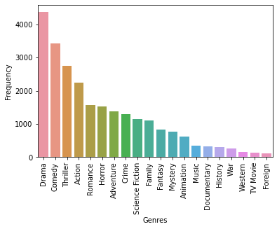

```python
# this is the barplot of genres against its frequency.
Plot_genres = pd.DataFrame.from_records(list(dict(fav_genre).items()))
Plot_genre = Plot_genres.sort_values(1, ascending=False)
plt.xticks(rotation=90)
sb.barplot(x=0, y=1, data=Plot_genres)
plt.xlabel("Genres")
plt.ylabel("Frequency")
```

We can see clearly that genre of the movie has the highest chance of being classified to Drama, followed by Comedy and Thriller. Dramatic and comic genres are mostly produced.

```python
# I wanted to know which cast appears mostly on the movies. This code pulls the number of the appearance of cast in each movie
counted_cast = [elem for sublist in workable['cast'] for elem in sublist]
fav_cast = Counter(counted_cast).most_common(10)
fav_cast
```

```
[('Robert De Niro', 72),
 ('Samuel L. Jackson', 70),
 ('Bruce Willis', 62),
 ('Nicolas Cage', 61),
 ('Michael Caine', 52),
 ('Robin Williams', 51),
 ('Morgan Freeman', 49),
 ('John Goodman', 48),
 ('John Cusack', 48),
 ('Liam Neeson', 47)]
```

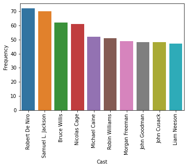

```python
Plot_cast = pd.DataFrame.from_records(list(dict(fav_cast).items()))
Plot_casts = Plot_cast.sort_values(1, ascending=False)
plt.xticks(rotation=90)
sb.barplot(x=0, y=1, data=Plot_cast)
plt.xlabel("Cast")
plt.ylabel("Frequency")
```

Now we can tell that Robert De Niro is the leading making appearence of 72 times in the produced movies followed by Samual L. Jackson then Bruce Willis in the best three appearance category.

```python
counted_companies = [elem for sublist in workable['production_companies'] for elem in sublist]
fav_companies = Counter(counted_companies).most_common(10)
fav_companies
```

```
[('Universal Pictures', 522),
 ('Warner Bros.', 509),
 ('Paramount Pictures', 431),
 ('Twentieth Century Fox Film Corporation', 282),
 ('Columbia Pictures', 272),
 ('New Line Cinema', 219),
 ('Metro-Goldwyn-Mayer (MGM)', 218),
 ('Walt Disney Pictures', 213),
 ('Touchstone Pictures', 178),
 ('Columbia Pictures Corporation', 160)]
```

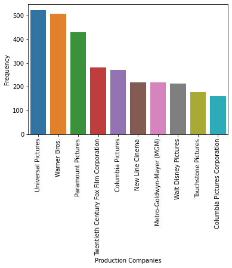

```python
Plot_companies = pd.DataFrame.from_records(list(dict(fav_companies).items()))
Plot_company = Plot_companies.sort_values(1, ascending=False)
plt.xticks(rotation=90)
sb.barplot(x=0, y=1, data=Plot_companies)
plt.xlabel("Production Companies")
plt.ylabel("Frequency")
```

Universal pictures has produced many movies 522 times when compared to the others followed by Warner Bros. and Paramoun pictures in top 3 category.

# Question 1 : Best Director Awards Campaign

```python
for category in ['budget_adj', 'revenue_adj', 'profit']:
    display(workable[[f'{category}', 'director']].sort_values(f'{category}', ascending=False).head(10))
```

|  | budget_adj | director |
| --- | --- | --- |
| 2244 | 4.250000e+08 | Sngmoo Lee |
| 3375 | 3.683713e+08 | Rob Marshall |
| 7387 | 3.155006e+08 | Gore Verbinski |
| 6570 | 2.920507e+08 | Bryan Singer |
| 5231 | 2.716921e+08 | James Cameron |
| 7394 | 2.713305e+08 | Sam Raimi |
| 1929 | 2.600000e+08 | Nathan Greno\|Byron Howard |
| 14 | 2.575999e+08 | Joss Whedon |
| 1389 | 2.541001e+08 | David Yates |
| 8089 | 2.504192e+08 | Kevin Reynolds |

|  | revenue_adj | director |
| --- | --- | --- |
| 1386 | 2.827124e+09 | James Cameron |
| 1329 | 2.789712e+09 | George Lucas |
| 5231 | 2.506406e+09 | James Cameron |
| 10594 | 2.167325e+09 | William Friedkin |
| 9806 | 1.907006e+09 | Steven Spielberg |
| 3 | 1.902723e+09 | J.J. Abrams |
| 8889 | 1.791694e+09 | Steven Spielberg |
| 8094 | 1.583050e+09 | Irwin Winkler |
| 10110 | 1.574815e+09 | Clyde Geronimi\|Hamilton Luske\|Wolfgang Reitherman |
| 4361 | 1.443191e+09 | Joss Whedon |

|  | profit | director |
| --- | --- | --- |
| 1329 | 2.750137e+09 | George Lucas |
| 1386 | 2.586237e+09 | James Cameron |
| 5231 | 2.234714e+09 | James Cameron |
| 10594 | 2.128036e+09 | William Friedkin |
| 9806 | 1.878643e+09 | Steven Spielberg |
| 8889 | 1.767968e+09 | Steven Spielberg |
| 3 | 1.718723e+09 | J.J. Abrams |
| 8094 | 1.551568e+09 | Irwin Winkler |
| 10110 | 1.545635e+09 | Clyde Geronimi\|Hamilton Luske\|Wolfgang Reitherman |
| 7309 | 1.376998e+09 | Irvin Kershner |

From the above findings we see that budgeting high would not transpire to higher profitsbut rather if one has higher revenue then it is an indicator of huge profits. For instance George Lucas and William Friendkin are not in the top list of budget but are on the top list of Revenue and profit. To have conclusive statement about these three variables let us see their correlation

```python
correlation= workable.corr()
correlation
```

|  | popularity | runtime | vote_count | vote_average | budget_adj | revenue_adj | release_month | profit |
| --- | --- | --- | --- | --- | --- | --- | --- | --- |
| popularity | 1.000000 | 0.156293 | 0.802956 | 0.239118 | 0.505372 | 0.606457 | 0.038025 | 0.561494 |
| runtime | 0.156293 | 1.000000 | 0.184291 | 0.194003 | 0.249119 | 0.198319 | 0.040918 | 0.160867 |
| vote_count | 0.802956 | 0.184291 | 1.000000 | 0.279858 | 0.580433 | 0.704045 | 0.029758 | 0.653545 |
| vote_average | 0.239118 | 0.194003 | 0.279858 | 1.000000 | 0.109750 | 0.214695 | 0.050607 | 0.217538 |
| budget_adj | 0.505372 | 0.249119 | 0.580433 | 0.109750 | 1.000000 | 0.640833 | 0.056010 | 0.466912 |
| revenue_adj | 0.606457 | 0.198319 | 0.704045 | 0.214695 | 0.640833 | 1.000000 | 0.049011 | 0.978075 |
| release_month | 0.038025 | 0.040918 | 0.029758 | 0.050607 | 0.056010 | 0.049011 | 1.000000 | 0.041263 |
| profit | 0.561494 | 0.160867 | 0.653545 | 0.217538 | 0.466912 | 0.978075 | 0.041263 | 1.000000 |

Correlation confirms that having higher revenue interprets higher profits when compared to higher budgeting. Also higher budgeting relatively transpire higher revenue. Also vote count and popularity play a role in budgetting, revenue and profit as correlation is relatively stronger. It is clear that having higher vote counts means you are popular. This is supported by stronger correlation.

```python
for category in ['popularity', 'vote_count', 'vote_average']:
    display(workable[[f'{category}', 'director']].sort_values(f'{category}', ascending=False).head(10))
```

|  | popularity | director |
| --- | --- | --- |
| 0 | 32.985763 | Colin Trevorrow |
| 1 | 28.419936 | George Miller |
| 629 | 24.949134 | Christopher Nolan |
| 630 | 14.311205 | James Gunn |
| 2 | 13.112507 | Robert Schwentke |
| 631 | 12.971027 | Joe Russo\|Anthony Russo |
| 1329 | 12.037933 | George Lucas |
| 632 | 11.422751 | Chad Stahelski\|David Leitch |
| 3 | 11.173104 | J.J. Abrams |
| 633 | 10.739009 | Francis Lawrence |

|  | vote_count | director |
| --- | --- | --- |
| 1919 | 9767 | Christopher Nolan |
| 4361 | 8903 | Joss Whedon |
| 1386 | 8458 | James Cameron |
| 2875 | 8432 | Christopher Nolan |
| 4364 | 7375 | Quentin Tarantino |
| 4382 | 7080 | Gary Ross |
| 5425 | 6882 | Shane Black |
| 4363 | 6723 | Christopher Nolan |
| 629 | 6498 | Christopher Nolan |
| 4367 | 6417 | Peter Jackson |

|  | vote_average | director |
| --- | --- | --- |
| 6911 | 8.7 | David Mallet |
| 8221 | 8.5 | Martin Scorsese\|Michael Henry Wilson |
| 8411 | 8.5 | Saul Swimmer |
| 3690 | 8.5 | Curt Morgan |
| 4178 | 8.4 | Frank Darabont |
| 609 | 8.4 | Andrew Jarecki |
| 5986 | 8.4 | Jorge Ramírez Suárez |
| 7948 | 8.4 | Jonathan Demme |
| 3310 | 8.3 | Kurt Kuenne |
| 7269 | 8.3 | Francis Ford Coppola |

# Question 2 : Best part of the year to release movie

```python
release_season = pd.DataFrame({"Month":workable["release_month"].value_counts().keys(), "Number of movies":workable["release_month"].value_counts().values})
release_season
```

|  | Month | Number of movies |
| --- | --- | --- |
| 0 | 1 | 1022 |
| 1 | 9 | 960 |
| 2 | 10 | 938 |
| 3 | 12 | 922 |
| 4 | 7 | 824 |
| 5 | 8 | 808 |
| 6 | 5 | 788 |
| 7 | 6 | 783 |
| 8 | 11 | 758 |
| 9 | 3 | 697 |
| 10 | 4 | 693 |
| 11 | 2 | 580 |

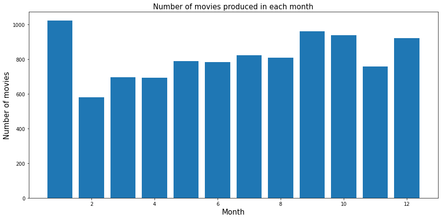

```python
plt.figure(figsize=(15,7))
plt.bar(release_season["Month"],release_season["Number of movies"])
plt.xlabel("Month",fontsize=15)
plt.ylabel("Number of movies",fontsize=15)
plt.title("Number of movies produced in each month", fontsize=15)
plt.show()
```

```python
def display_barplot(variable,ylabels,titles):
   """
    This function plots a bar chart and takes 3 arguments which is first is variable which represents data for plotting,
    second is ylabels whichs takes values for ylabel property of chart and lastly is titles which takes the values of title
    property of a chart.
    The purpose of this function to eliminate code repeat as I will be using matplotlib several times
   """
   plot_value = variable.plot(kind='bar',title=titles,ylabel=ylabels,xlabel='Release month',figsize=(10,6))
   return (plot_value)
```

The chart above shows that Junuary is when most movies are released and Fubruary having least number of movies being produced.

```python
monthly_budget = workable.groupby('release_month')['budget_adj'].mean()
monthly_budget
```

```
release_month
1     1.191900e+07
2     1.861674e+07
3     1.761328e+07
4     1.673765e+07
5     2.426480e+07
6     2.608458e+07
7     2.306014e+07
8     1.430005e+07
9     1.555086e+07
10    1.765112e+07
11    2.553442e+07
12    2.382531e+07
Name: budget_adj, dtype: float64
```

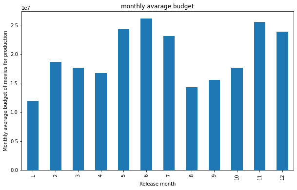

```python
# Calling display_barplot function with relevant arguments to plot our desired plot
display_barplot(monthly_budget,'Monthly average budget of movies for production','monthly avarage budget');
```

June is the most budgeted month for movie production followed closely by November and January being the lowest month being budgeted

```python
monthly_revenue = workable.groupby('release_month')['revenue_adj'].mean()
monthly_revenue
```

```
release_month
1     3.388648e+07
2     4.063840e+07
3     5.551415e+07
4     4.029175e+07
5     8.191840e+07
6     8.707209e+07
7     6.924067e+07
8     3.451595e+07
9     4.039223e+07
10    4.554290e+07
11    8.061367e+07
12    7.856043e+07
Name: revenue_adj, dtype: float64
```

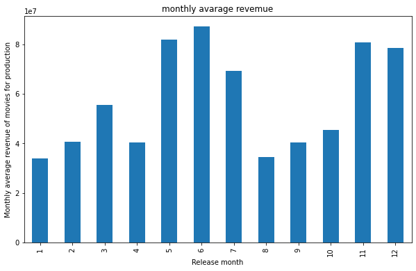

```python
# Calling display_barplot function with relevant arguments to plot our desired plot
display_barplot(monthly_revenue,'Monthly average revenue of movies for production','monthly avarage revemue');
```

There is a pick in revenue in the month of June and november while in January and August it is lowest

```python
monthly_profit = workable.groupby('release_month')['profit'].mean()
monthly_profit
```

```
release_month
1     2.196748e+07
2     2.202165e+07
3     3.790088e+07
4     2.355411e+07
5     5.765361e+07
6     6.098751e+07
7     4.618052e+07
8     2.021589e+07
9     2.484137e+07
10    2.789178e+07
11    5.507924e+07
12    5.473512e+07
Name: profit, dtype: float64
```

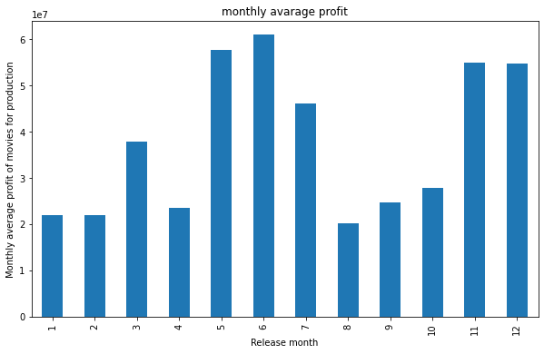

```python
# Calling display_barplot function with relevant arguments to plot our desired plot
display_barplot(monthly_profit,'Monthly average profit of movies for production','monthly avarage profit');
```

In the months of May, June, November and December the profits are high which in the monhts of January, February and August having lowest.

```python
#chenging datatype of release month to string for the purpose good classification by hue attribute in seaborn
workable['release_month']=workable['release_month'].astype(str)
```

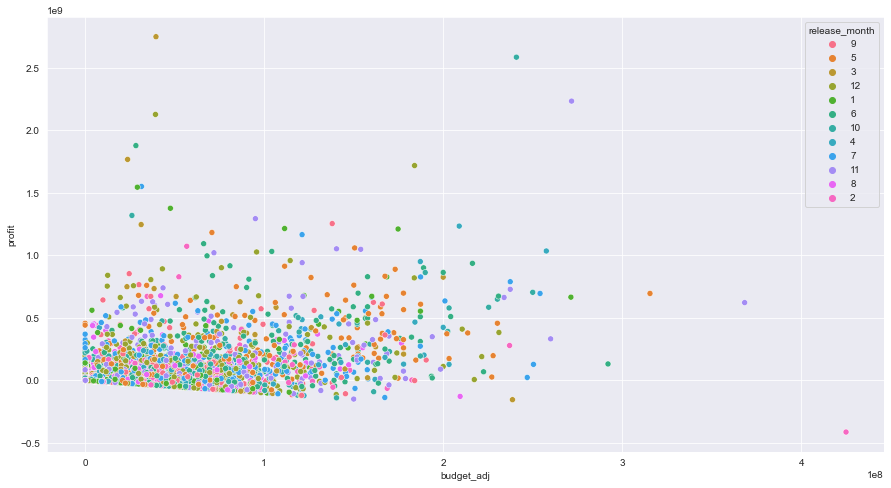

```python
plt.figure(figsize=(15, 8))
sb.set_style('darkgrid')
sb.scatterplot(data=workable, x="budget_adj", y="profit", hue="release_month");
```

```python
# changing back the release month datatype to string
workable['release_month']=workable['release_month'].astype(int)
```

```python
monthly_runtime = workable.groupby('release_month')['runtime'].mean()
monthly_runtime
```

```
release_month
1      99.937378
2     104.356897
3     102.708752
4     100.404040
5     104.906091
6     103.586207
7     102.035194
8     100.372525
9     103.985417
10    100.488273
11    104.236148
12    108.473970
Name: runtime, dtype: float64
```

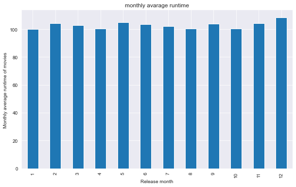

```python
# Calling display_barplot function with relevant arguments to plot our desired plot
display_barplot(monthly_runtime,'Monthly average runtime of movies ','monthly avarage runtime');
```

In terms of movie runtime there is no significant diffence.

```python
monthly_popularity = workable.groupby('release_month')['popularity'].mean()
monthly_popularity
```

```
release_month
1     0.545258
2     0.649634
3     0.700896
4     0.602629
5     0.840042
6     0.767585
7     0.750221
8     0.593185
9     0.652144
10    0.730669
11    0.792554
12    0.733831
Name: popularity, dtype: float64
```

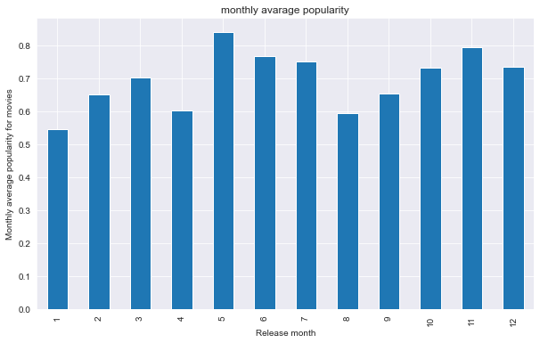

```python
# Calling display_barplot function with relevant arguments to plot our desired plot
display_barplot(monthly_popularity,'Monthly average popularity for movies','monthly avarage popularity');
```

Movies produced in the month of May are Most popular followed closely by November while in January and August being least popular

```python
monthly_votecount = workable.groupby('release_month')['vote_count'].mean()
monthly_votecount
```

```
release_month
1     163.690802
2     207.713793
3     226.741750
4     197.313131
5     330.675127
6     300.759898
7     293.898058
8     169.855198
9     198.905208
10    247.616205
11    289.317942
12    258.271150
Name: vote_count, dtype: float64
```

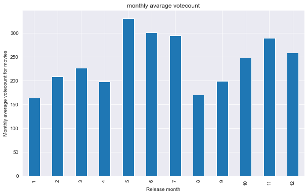

```python
# Calling display_barplot function with relevant arguments to plot our desired plot
display_barplot(monthly_votecount,'Monthly average votecount for movies','monthly avarage votecount');
```

Most voted movies are those release in the month of May and June while in January and August being voted least

# Report

### Limitation.

Production companies variable had the most missing values and it was useful for some part of my analysis. With the nature of its data type there is no way to fill them hence there was need to drop and it affected the structure of my data significantly. With more than 1000 rows being dropped I would say my data didn't really reflect what it is suppose to. Vizualizing by using scatter plot would bear so much evidence about the relationship of variables which I needed to generate correlation table so that I could get supporting and reliable evidence. My major platform for reference was Kaggle where was the source of dataset where I looked at some of worked examples, I also made reference to stackoverflow and towardsdatascience sites as listed bellow https://www.kaggle.com/code/shanmuhapriyaaraju/assignment1 https://stackoverflow.com/questions/40353519/how-to-apply-custom-function-to-pandas-data-frame-for-each-row https://towardsdatascience.com/applying-custom-functions-to-groups-of-data-in-pandas-928d7eece0aa